# Searching for R Packages

One of the most vexing problems for R users, and experienced alike, is to find packages with functions that can halp you do some new task. Recently, within the past year or so, a few packages have been written to help. The following recreates my strategy, more or less, to find what’s out there for plotting [ROC curves](https://rviews.rstudio.com/2019/01/17/roc-curves/).

### Packages for Searching

There are two promary packages for searching `CRAN`: packagefinder and [pkgesearch](https://CRAN.R-project.org/package=pkgsearch).

I will be using Gábor Csárdi’s `pkgsearch` package, which is newer and has better documantation. You can find a blog post which used `packagefinder` [here](https://rviews.rstudio.com/2018/10/22/searching-for-r-packages/).

```r
library(tidyverse)  # for data manipulation
library(dlstats)    # for package download stats
#library(packagefinder) # for searching packages
library(pkgsearch)  # for searching packages
```

### Searching with `pkgsearch`

First we try some exploratory work to settle on a query. The documentation says:

Ranking:

> The most important feature of a search engine is the ranking of the results. The best results should be listed first. pkgsearch uses weighted scoring, where a match in the package title gets a higher score than a match in the package desciption. It also uses the number of reverse dependencies and the number of downloads to weight the scores:

Preferring Phrases:

> The search engine prefers matching whole phrases over single words. E.g. the search phrase “permutation test” will rank coin higher than testthat, even though testthat is a much better result for the single word “test”.

```r
r1 <- as_tibble(pkg_search("Receiver Operating Characteristic"))
names(r1)
```

```
 [1] "score"                "package"              "version"
 [4] "title"                "description"          "date"
 [7] "maintainer_name"      "maintainer_email"     "revdeps"
[10] "downloads_last_month" "license"              "url"
[13] "bugreports"           "package_data"
```

```r
r1 %>% select(score, package, revdeps, downloads_last_month)
```

| score | package | revdeps | downloads_last_month |
| --- | --- | --- | --- |
| 4074.8977 | precrec | 3 | 502 |
| 3559.2039 | pROC | 64 | 36554 |
| 3184.8960 | ROCS | 1 | 253 |
| 2812.7305 | RcmdrPlugin.ROC | 1 | 437 |
| 2629.7227 | AROC | 1 | 301 |
| 2624.5090 | fbroc | 1 | 301 |
| 1910.7566 | nproc | 1 | 314 |
| 1250.1315 | AUC | 8 | 3863 |
| 564.9236 | npROCRegression | 1 | 243 |
| 564.5890 | tpAUC | 1 | 209 |

```r
r2 <- as_tibble(pkg_search("ROC"))
r2 %>% select(score, package, revdeps, downloads_last_month)
```

| score | package | revdeps | downloads_last_month |
| --- | --- | --- | --- |
| 7950.531 | pROC | 64 | 36554 |
| 3445.483 | caTools | 26 | 206368 |
| 1566.565 | survivalROC | 5 | 1015 |
| 1326.994 | PRROC | 3 | 8121 |
| 1183.829 | precrec | 3 | 502 |
| 1145.296 | WeightedROC | 1 | 301 |
| 1106.481 | surrosurvROC | 1 | 157 |
| 1079.992 | rocc | 1 | 367 |
| 1050.585 | cvAUC | 2 | 1180 |
| 1023.377 | risksetROC | 2 | 423 |

```r
r3 <- as_tibble(pkg_search(" Receiver Operating Characteristic Curve, ROC"))
r3 %>% select(score, package, revdeps, downloads_last_month)
```

| score | package | revdeps | downloads_last_month |
| --- | --- | --- | --- |
| 2546.6040 | pROC | 64 | 36554 |
| 2158.6274 | precrec | 3 | 502 |
| 1021.0606 | nproc | 1 | 314 |
| 347.6180 | sROC | 1 | 3443 |
| 331.1413 | WeightedROC | 1 | 301 |
| 326.5951 | nsROC | 1 | 238 |
| 316.0297 | AROC | 1 | 301 |
| 312.3097 | ROCS | 1 | 253 |
| 302.4692 | magrittr | 809 | 513444 |
| 289.4300 | fbroc | 1 | 301 |

```r
rocPkgs  <- as_tibble(pkg_search(query="Receiver Operating Characteristic, ROC",size=400))
```

```r
topRoc <- rocPkgs %>% filter(score > 15)
dim(topRoc)
```

```
[1] 63 14
```

```r
topRoc %>% select(score, package, title) %>% head
```

| score | package | title |
| --- | --- | --- |
| 5176.1143 | pROC | Display and Analyze ROC Curves |
| 1806.9552 | precrec | Calculate Accurate Precision-Recall and ROC (Receiver Operator\nCharacteristics) Curves |
| 1009.6182 | nproc | Neyman-Pearson (NP) Classification Algorithms and NP Receiver\nOperating Characteristic (NP-ROC) Curves |
| 803.2754 | bcROCsurface | Bias-Corrected Methods for Estimating the ROC Surface of\nContinuous Diagnostic Tests |
| 800.0655 | npROCRegression | Kernel-Based Nonparametric ROC Regression Modelling |
| 787.9945 | sROC | Nonparametric Smooth ROC Curves for Continuous Data |

### The Tough Part

Looking through the packages selected with scores > 15, I selected 6 packages that I thought would meet most peoples plotting needs. I did not select any of the packages made to used with survial data. That would be a much more specialized need,

```r
shortList <- rocPkgs %>% filter(package %in% c("pROC","precrec","ROCit", "PRROC","ROCR","plotROC")) %>%
            select(score, package, revdeps, title, description )
shortList
```

| score | package | revdeps | title | description |
| --- | --- | --- | --- | --- |
| 5176.11430 | pROC | 64 | Display and Analyze ROC Curves | Tools for visualizing, smoothing and comparing receiver operating characteristic (ROC curves). (Partial) area under the curve (AUC) can be compared with statistical tests based on U-statistics or boot… |
| 1806.95520 | precrec | 3 | Calculate Accurate Precision-Recall and ROC (Receiver Operator\nCharacteristics) Curves | Accurate calculations and visualization of precision-recall and ROC (Receiver Operator Characteristics)\ncurves. |
| 309.77786 | ROCit | 1 | Performance Assessment of Binary Classifier with Visualization | Sensitivity (or recall or true positive rate), false positive rate, specificity, precision (or positive predictive value), negative predictive value, misclassification rate, accuracy, F-score- these a… |
| 22.03390 | ROCR | 69 | Visualizing the Performance of Scoring Classifiers | ROC graphs, sensitivity/specificity curves, lift charts,and precision/recall plots are popular examples of trade-offvisualizations for specific pairs of performance measures. ROCR is aflexible tool fo… |
| 16.86351 | plotROC | 2 | Generate Useful ROC Curve Charts for Print and Interactive Use | Most ROC curve plots obscure the cutoff values and inhibit\ninterpretation and comparison of multiple curves. This attempts to address\nthose shortcomings by providing plotting and interactive tools. … |
| 15.91384 | PRROC | 3 | Precision-Recall and ROC Curves for Weighted and Unweighted Data | Computes the areas under the precision-recall (PR) and ROC curve for weighted (e.g., soft-labeled) and unweighted data. In contrast to other implementations, the interpolation between points of the PR… |

### A Closer Look at Downloads

Now, we us Guangchuang Yu’s `dlstats` package to take a closer looka at downloads.

```r
downloads <- cran_stats(shortList$package)
topDown <- downloads %>% group_by(package) %>% summarize(downloads = sum(downloads)) %>%
           arrange(desc(downloads))
rocFinal <- right_join(shortList,topDown)
dim(rocFinal)
```

```
[1] 6 6
```

```r
rocFinal %>% select(package, score, downloads)
```

| package | score | downloads |
| --- | --- | --- |
| ROCR | 22.03390 | 1260007 |
| pROC | 5176.11430 | 992799 |
| PRROC | 15.91384 | 47992 |
| plotROC | 16.86351 | 40886 |
| precrec | 1806.95520 | 12699 |
| ROCit | 309.77786 | 33 |

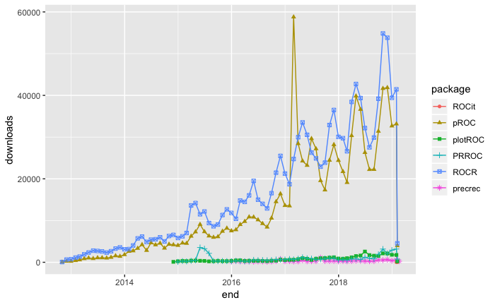

```r
ggplot(downloads, aes(end, downloads, group=package, color=package)) +
  geom_line() + geom_point(aes(shape=package))
```

```r
allROC <- pkg_search(query="Receiver Operating Characteristic, ROC",
             format = "short",
              size=10000)
dim(allROC)
```

[output not shown]